# Analysis performed in [Gulone et al 2023](https://www.liebertpub.com/doi/10.1089/mdr.2023.0219)

This is an [R Markdown](http://rmarkdown.rstudio.com) Notebook containing code used to analyse metadata of *S. aureus* bacteremia in an Argentinean University Hospital during an 8-year period (2009-2016). A total of 326 *S. aureus* clinical isolates were recovered in three periods: P1: 2009-2010, P2: 2012-2014, and P3: 2015-2016. The results of each analysis appear beneath the code.

```r
#loading libraries
library(tidyverse)
library(readr)
library(dplyr)
library(ggplot2)
library(ggsci)
library(scales)
library(gridExtra)
```

## **MRSA isolates susceptibility profile**

Despite the percentages of patients with SAB infected by MRSA were similar in the three periods (44/92, 47.8%; 44/88, 50%; and 39/97, 40.2 % in each period respectively), we observed a concomitant decrease in multiple drug resistance (MDR) among MRSA isolates

```r
BACTERIEMIAS_SAMR_2009_2016_MLS.mod%>%
  group_by(Period)%>%
  count(Bact_isolated)
```

| Period | Bact_isolated | n |
| --- | --- | --- |
| P1 | MRSA | 44 |
| P2 | MRSA | 44 |
| P3 | MRSA | 39 |

```r
BACTERIEMIAS_SAMR_2009_2016_MLS.mod%>%
  group_by(Period)%>%
  count(MDR)%>%
  mutate(pct=n/sum(n)*100)
```

| Period | MDR | n | pct |
| --- | --- | --- | --- |
| P1 | No | 17 | 38.63636 |
| P1 | Yes | 27 | 61.36364 |
| P2 | No | 18 | 40.90909 |
| P2 | Yes | 26 | 59.09091 |
| P3 | No | 29 | 74.35897 |
| P3 | Yes | 10 | 25.64103 |

```r
MDR_pos = c(27,26,10)
MDR_n = c(44,44,39)
prop.test(MDR_pos,MDR_n)
```

```
    3-sample test for equality of proportions without continuity correction

data:  MDR_pos out of MDR_n
X-squared = 12.977, df = 2, p-value = 0.001521
alternative hypothesis: two.sided
sample estimates:
   prop 1    prop 2    prop 3
0.6136364 0.5909091 0.2564103
```

```r
prop.trend.test(MDR_pos,MDR_n)
```

```
    Chi-squared Test for Trend in Proportions

data:  MDR_pos out of MDR_n ,
 using scores: 1 2 3
X-squared = 10.185, df = 1, p-value = 0.001416
```

Susceptibility profiles, particularly the resistance rates for erythromycin, clindamycin and fluoroquinolones (ciprofloxacin and/or levofloxacin) significantly decrease through time (p = 0.002262, p = 0.0002629, and p = 0.0005516 for each antimicrobial agent respectively)

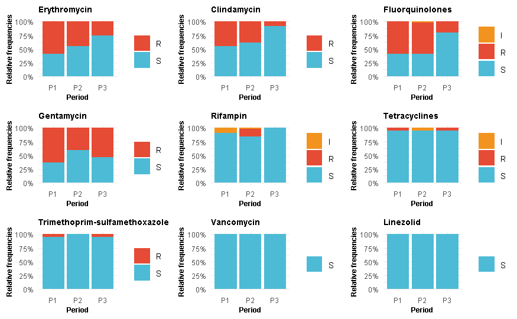

```r
#Graph ERY resistance phenotype by period
ery <- BACTERIEMIAS_SAMR_2009_2016_MLS.mod%>%
  group_by(ERY_Phenotype)%>%
  ggplot(aes(Period, fill=ERY_Phenotype)) +
  geom_bar(position="fill")+
  theme_minimal()+
  theme(title = element_text(size=7, face="bold"),
        axis.text=element_text(size=7),
        axis.title=element_text(size=7,face="bold"),
        legend.text = element_text(size = 8),
        legend.title = element_blank())+
  scale_y_continuous(labels=scales::percent) +
  scale_fill_manual(values = c("I"="#f2931f",
                               "R"="#E64B35FF",
                               "S"="#4DBBD5FF"))+
  labs(y="Relative frequencies",
       title="Erythromycin")

#Graph CLIN resistance phenotype by period
clin<-BACTERIEMIAS_SAMR_2009_2016_MLS.mod%>%
  group_by(CLIN_Phenotype)%>%
  ggplot(aes(Period, fill=CLIN_Phenotype)) +
  geom_bar(position="fill")+
  theme_minimal()+
  theme(title = element_text(size=7, face="bold"),
        axis.text=element_text(size=7),
        axis.title=element_text(size=7,face="bold"),
        legend.text = element_text(size = 8),
        legend.title = element_blank())+
  scale_y_continuous(labels=scales::percent) +
  scale_fill_manual(values = c("I"="#f2931f",
                               "R"="#E64B35FF",
                               "S"="#4DBBD5FF"))+
  labs(y="Relative frequencies",
       title="Clindamycin")

#Graph GEN resistance phenotype by period
gen<-BACTERIEMIAS_SAMR_2009_2016_MLS.mod%>%
  group_by(GEN_Phenotype)%>%
  ggplot(aes(Period, fill=GEN_Phenotype)) +
  geom_bar(position="fill")+
  theme_minimal()+
  theme(title = element_text(size=7, face="bold"),
        axis.text=element_text(size=7),
        axis.title=element_text(size=7,face="bold"),
        legend.text = element_text(size = 8),
        legend.title = element_blank())+
  scale_y_continuous(labels=scales::percent) +
  scale_fill_manual(values = c("I"="#f2931f",
                               "R"="#E64B35FF",
                               "S"="#4DBBD5FF"))+
  labs(y="Relative frequencies",
       title="Gentamycin")


#Graph tet (tet+min) resistance phenotype by period
tet<-BACTERIEMIAS_SAMR_2009_2016_MLS.mod%>%
  group_by(Tetraclyclines_phenotype)%>%
  ggplot(aes(Period, fill=Tetraclyclines_phenotype)) +
  geom_bar(position="fill")+
  theme_minimal()+
  theme(title = element_text(size=7, face="bold"),
        axis.text=element_text(size=7),
        axis.title=element_text(size=7,face="bold"),
        legend.text = element_text(size = 8),
        legend.title = element_blank())+
  scale_y_continuous(labels=scales::percent) +
  scale_fill_manual(values = c("I"="#f2931f",
                               "R"="#E64B35FF",
                               "S"="#4DBBD5FF"))+
  labs(y="Relative frequencies",
       title="Tetracyclines")


#Graph RIF resistance phenotype by period
rif<-BACTERIEMIAS_SAMR_2009_2016_MLS.mod%>%
  group_by(RIF_Phenotype)%>%
  ggplot(aes(Period, fill=RIF_Phenotype)) +
  geom_bar(position="fill")+
  theme_minimal()+
  theme(title = element_text(size=7, face="bold"),
        axis.text=element_text(size=7),
        axis.title=element_text(size=7,face="bold"),
        legend.text = element_text(size = 8),
        legend.title = element_blank())+
  scale_y_continuous(labels=scales::percent) +
  scale_fill_manual(values = c("I"="#f2931f",
                               "R"="#E64B35FF",
                               "S"="#4DBBD5FF"))+
  labs(y="Relative frequencies",
       title="Rifampin")


#Graph fluoroquinolones (CIP+LEV) resistance phenotype by period
fq<-BACTERIEMIAS_SAMR_2009_2016_MLS.mod%>%
  group_by(Fluorquinolones_phenotype)%>%
  ggplot(aes(Period, fill=Fluorquinolones_phenotype)) +
  geom_bar(position="fill")+
  theme_minimal()+
  theme(title = element_text(size=7, face="bold"),
        axis.text=element_text(size=7),
        axis.title=element_text(size=7,face="bold"),
        legend.text = element_text(size = 8),
        legend.title = element_blank())+
  scale_y_continuous(labels=scales::percent) +
  scale_fill_manual(values = c("I"="#f2931f",
                               "R"="#E64B35FF",
                               "S"="#4DBBD5FF"))+
  labs(y="Relative frequencies",
       title="Fluorquinolones")


#Graph tms resistance phenotype by period
tms<-BACTERIEMIAS_SAMR_2009_2016_MLS.mod%>%
  group_by(TMS_Phenotype)%>%
  ggplot(aes(Period, fill=TMS_Phenotype)) +
  geom_bar(position="fill")+
  theme_minimal()+
  theme(title = element_text(size=7, face="bold"),
        axis.text=element_text(size=7),
        axis.title=element_text(size=7,face="bold"),
        legend.text = element_text(size = 8),
        legend.title = element_blank())+
  scale_y_continuous(labels=scales::percent) +
  scale_fill_manual(values = c("I"="#f2931f",
                               "R"="#E64B35FF",
                               "S"="#4DBBD5FF"))+
  labs(y="Relative frequencies",
       title="Trimethoprim-sulfamethoxazole")

#Graph VAN resistance phenotype by period
van<-BACTERIEMIAS_SAMR_2009_2016_MLS.mod%>%
  group_by(VAN_Phenotype)%>%
  ggplot(aes(Period, fill=VAN_Phenotype)) +
  geom_bar(position="fill")+
  theme_minimal()+
  theme(title = element_text(size=7, face="bold"),
        axis.text=element_text(size=7),
        axis.title=element_text(size=7,face="bold"),
        legend.text = element_text(size = 8),
        legend.title = element_blank())+
  scale_y_continuous(labels=scales::percent) +
  scale_fill_manual(values = c("I"="#f2931f",
                               "R"="#E64B35FF",
                               "S"="#4DBBD5FF"))+
  labs(y="Relative frequencies",
       title="Vancomycin")

#Graph LZD resistance phenotype by period
lzd<-BACTERIEMIAS_SAMR_2009_2016_MLS.mod%>%
  group_by(LZD_Phenotype)%>%
  ggplot(aes(Period, fill=LZD_Phenotype)) +
  geom_bar(position="fill")+
  theme_minimal()+
  theme(title = element_text(size=7, face="bold"),
        axis.text=element_text(size=7),
        axis.title=element_text(size=7,face="bold"),
        legend.text = element_text(size = 8),
        legend.title = element_blank())+
  scale_y_continuous(labels=scales::percent) +
  scale_fill_manual(values = c("I"="#f2931f",
                               "R"="#E64B35FF",
                               "S"="#4DBBD5FF"))+
  labs(y="Relative frequencies",
       title="Linezolid")

#join graphs into one
grid.arrange(ery, clin, fq, gen,  rif, tet, tms, van, lzd,
             nrow = 3,
             ncol = 3)
```

**Erythromycin**

```r
#Count ERY resistance phenotype by period
BACTERIEMIAS_SAMR_2009_2016_MLS.mod%>%
  group_by(Period)%>%
  count(ERY_Phenotype)%>%
  mutate(pct=n/sum(n)*100)
```

| Period | ERY_Phenotype | n | pct |
| --- | --- | --- | --- |
| P1 | R | 26 | 59.09091 |
| P1 | S | 18 | 40.90909 |
| P2 | R | 20 | 45.45455 |
| P2 | S | 24 | 54.54545 |
| P3 | R | 10 | 25.64103 |
| P3 | S | 29 | 74.35897 |

```r
#define ERY R positives and negatives and perform prop test
ERY_R_pos = c(26,20,10)
ERY_R_n = c(44,44,39)
prop.test(ERY_R_pos,ERY_R_n)
```

```
    3-sample test for equality of proportions without continuity correction

data:  ERY_R_pos out of ERY_R_n
X-squared = 9.4346, df = 2, p-value = 0.00894
alternative hypothesis: two.sided
sample estimates:
   prop 1    prop 2    prop 3
0.5909091 0.4545455 0.2564103
```

```r
prop.trend.test(ERY_R_pos,ERY_R_n)
```

```
    Chi-squared Test for Trend in Proportions

data:  ERY_R_pos out of ERY_R_n ,
 using scores: 1 2 3
X-squared = 9.3234, df = 1, p-value = 0.002262
```

**Clindamycin**

```r
BACTERIEMIAS_SAMR_2009_2016_MLS.mod%>%
  group_by(Period)%>%
  count(CLIN_Phenotype)%>%
  mutate(pct=n/sum(n)*100)
```

| Period | CLIN_Phenotype | n | pct |
| --- | --- | --- | --- |
| P1 | R | 20 | 45.454545 |
| P1 | S | 24 | 54.545455 |
| P2 | R | 17 | 38.636364 |
| P2 | S | 27 | 61.363636 |
| P3 | R | 3 | 7.692308 |
| P3 | S | 36 | 92.307692 |

```r
CLIN_R_pos = c(20,17,3)
CLIN_R_n = c(44,44,39)
prop.test(CLIN_R_pos,CLIN_R_n)
```

```
    3-sample test for equality of proportions without continuity correction

data:  CLIN_R_pos out of CLIN_R_n
X-squared = 15.255, df = 2, p-value = 0.0004869
alternative hypothesis: two.sided
sample estimates:
    prop 1     prop 2     prop 3
0.45454545 0.38636364 0.07692308
```

```r
prop.trend.test(CLIN_R_pos,CLIN_R_n)
```

```
    Chi-squared Test for Trend in Proportions

data:  CLIN_R_pos out of CLIN_R_n ,
 using scores: 1 2 3
X-squared = 13.318, df = 1, p-value = 0.0002629
```

**Fluoroquinolones**

```r
BACTERIEMIAS_SAMR_2009_2016_MLS.mod%>%
   group_by(Period)%>%
   count(Fluorquinolones_phenotype)
```

| Period | Fluorquinolones_phenotype | n |
| --- | --- | --- |
| P1 | R | 26 |
| P1 | S | 18 |
| P2 | I | 1 |
| P2 | R | 25 |
| P2 | S | 18 |
| P3 | R | 8 |
| P3 | S | 31 |

```r
FQ_R_pos = c(26,25,8)
FQ_R_n = c(44,44,39)
prop.test(FQ_R_pos,FQ_R_n)
```

```
    3-sample test for equality of proportions without continuity correction

data:  FQ_R_pos out of FQ_R_n
X-squared = 15.276, df = 2, p-value = 0.0004819
alternative hypothesis: two.sided
sample estimates:
   prop 1    prop 2    prop 3
0.5909091 0.5681818 0.2051282
```

```r
prop.trend.test(FQ_R_pos,FQ_R_n)
```

```
    Chi-squared Test for Trend in Proportions

data:  FQ_R_pos out of FQ_R_n ,
 using scores: 1 2 3
X-squared = 11.933, df = 1, p-value = 0.0005516
```

## **Molecular characterization**

When performing molecular characterization of the MRSA isolates we found a remarkable raise in isolates carrying SCCmec type IV between the three periods: increasing from 38.6% (17/44) in P1 to 59.1% (26/44) in P2 and finally reaching 87.2% (34/39) in P3 (Figure 2, p = 6.615e-06).

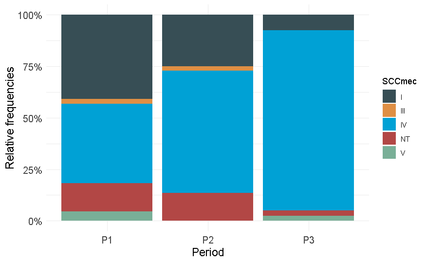

```r
SCCmec_period<-BACTERIEMIAS_SAMR_2009_2016_MLS.mod%>%
  group_by(SCCmec)%>%
  ggplot(aes(Period, fill=SCCmec)) +
  geom_bar(position="fill")+
  theme_minimal()+
  theme(axis.text = element_text(size = 12),
        axis.title = element_text(size = 14))+
  scale_fill_jama()+
  scale_y_continuous(labels=scales::percent) +
  labs(y="Relative frequencies")

SCCmec_period
```

```r
BACTERIEMIAS_SAMR_2009_2016_MLS.mod%>%
  group_by(Period)%>%
  count(SCCmec)%>%
  mutate(pct=n/sum(n)*100)
```

| Period | SCCmec | n | pct |
| --- | --- | --- | --- |
| P1 | I | 18 | 40.909091 |
| P1 | III | 1 | 2.272727 |
| P1 | IV | 17 | 38.636364 |
| P1 | NT | 6 | 13.636364 |
| P1 | V | 2 | 4.545455 |
| P2 | I | 11 | 25.000000 |
| P2 | III | 1 | 2.272727 |
| P2 | IV | 26 | 59.090909 |
| P2 | NT | 6 | 13.636364 |
| P3 | I | 3 | 7.692308 |

[output cut: 3 more lines]

```r
SCCmecIV_pos = c(17,26,34)
SCCmecIV_n = c(44,44,39)
prop.test(SCCmecIV_pos,SCCmecIV_n)
```

```
    3-sample test for equality of proportions without continuity correction

data:  SCCmecIV_pos out of SCCmecIV_n
X-squared = 20.477, df = 2, p-value = 3.577e-05
alternative hypothesis: two.sided
sample estimates:
   prop 1    prop 2    prop 3
0.3863636 0.5909091 0.8717949
```

```r
prop.trend.test(SCCmecIV_pos,SCCmecIV_n)
```

```
    Chi-squared Test for Trend in Proportions

data:  SCCmecIV_pos out of SCCmecIV_n ,
 using scores: 1 2 3
X-squared = 20.301, df = 1, p-value = 6.615e-06
```

SCCmec type IV isolates were mainly susceptible to antibiotics other than beta-lactams as previously described in our country and therefore exhibited low MDR rates

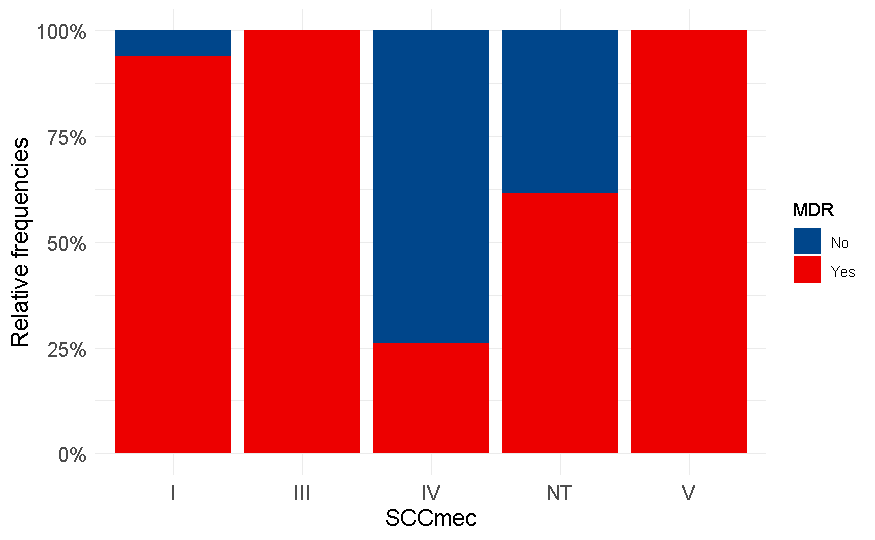

```r
SCCmec_A<-BACTERIEMIAS_SAMR_2009_2016_MLS.mod%>%
  group_by(MDR)%>%
  ggplot(aes(SCCmec, fill=MDR)) +
  geom_bar(position="fill")+
  theme_minimal()+
  theme(axis.text = element_text(size = 12),
        axis.title = element_text(size = 14))+
  scale_fill_lancet()+
  scale_y_continuous(labels=scales::percent) +
  labs(y="Relative frequencies")
SCCmec_A
```

We observed a negative trend (13/17, 13/26, and 16/34 MRSA-IV isolates in P1, P2, and P3, respectively, p = 0.06684) in the carriage of PVL encoding genes (lukS/F-PV) among SCCmecIV isolates, despite the presence of PVL genes in 20-30% of MRSA isolates recovered in the three periods.

```r
BACTERIEMIAS_SAMR_2009_2016_MLS.mod%>%
  filter(SCCmec=="IV")%>%
  group_by(Period)%>%
  count(PVL)%>%
  mutate(pct=n/sum(n)*100)
```

| Period | PVL | n | pct |
| --- | --- | --- | --- |
| P1 | negative | 4 | 23.52941 |
| P1 | positive | 13 | 76.47059 |
| P2 | negative | 13 | 50.00000 |
| P2 | positive | 13 | 50.00000 |
| P3 | negative | 18 | 52.94118 |
| P3 | positive | 16 | 47.05882 |

```r
pvl_pos = c(13,13,16)
pvl_n = c(17,26,34)
prop.test(pvl_pos,pvl_n)
```

```
    3-sample test for equality of proportions without continuity correction

data:  pvl_pos out of pvl_n
X-squared = 4.2814, df = 2, p-value = 0.1176
alternative hypothesis: two.sided
sample estimates:
   prop 1    prop 2    prop 3
0.7647059 0.5000000 0.4705882
```

```r
prop.trend.test(pvl_pos,pvl_n)
```

```
    Chi-squared Test for Trend in Proportions

data:  pvl_pos out of pvl_n ,
 using scores: 1 2 3
X-squared = 3.359, df = 1, p-value = 0.06684
```

Most isolates harboring SCCmec I between 2009-2016 belong to ST5-MRSA-I (related to HA-MRSA Cordobés clone). However, the increase of isolates harboring SCCmec IV was not due to a single clone but rather it was associated to different CA-MRSA lineages. During P2 other lineages harbouring SCCmec IV such as ST8-MRSA-IV and ST97-MRSA-IV appeared, and their rates also increased during P3. Remarkably, the elevated proportion of SCCmec IV during P3 (34/39 MRSA isolates), was due mainly by three major genotypes: ST30-MRSA-IV, ST8-MRSA-IV and ST5-MRSA-IV (23.1% and 20.5% and 20.5%, respectively)

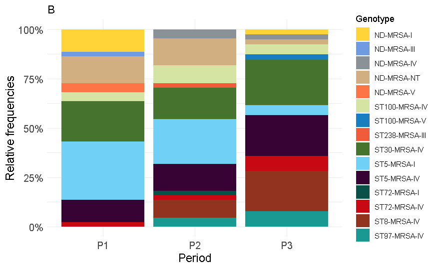

```r
Genotype_period<-BACTERIEMIAS_SAMR_2009_2016_MLS.mod%>%
  group_by(Genotype)%>%
  ggplot(aes(Period, fill=Genotype)) +
  geom_bar(position="fill")+
  theme_minimal()+
  theme(axis.text = element_text(size = 12),
        axis.title = element_text(size = 14))+
  scale_fill_simpsons()+
  scale_y_continuous(labels=scales::percent) +
  labs(y="Relative frequencies",
       title="B")

Genotype_period
```

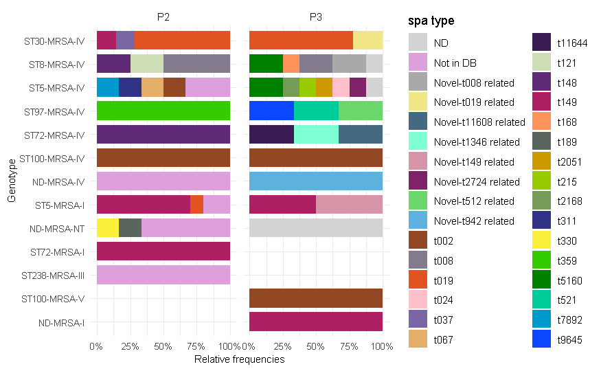

```r
spageno2<-BACTERIEMIAS_SAMR_2009_2016_MLS.mod%>%
  group_by(spa_type)%>%
  filter(Period!="P1")
spageno2$Genotype <- factor(spageno2$Genotype,
                              levels = c("ND-MRSA-I",
                                         "ST100-MRSA-V",
                                         "ST238-MRSA-III",
                                         "ST72-MRSA-I",
                                         "ND-MRSA-NT",
                                         "ST5-MRSA-I",
                                         "ND-MRSA-IV",
                                         "ST100-MRSA-IV",
                                         "ST72-MRSA-IV",
                                         "ST97-MRSA-IV",
                                         "ST5-MRSA-IV",
                                         "ST8-MRSA-IV",
                                         "ST30-MRSA-IV"
                              ))

spageno3<-  ggplot(spageno2, aes(x=Genotype, fill=spa_type)) +
  geom_bar(position="fill",
           width = 0.8)+
  theme_minimal()+
  theme(axis.text = element_text(size = 8),
        axis.title = element_text(size = 9))+
  scale_fill_manual(values = c("ND"="#D3D3D3",
                               "Not in DB"="#DDA0DD",
                               "Novel-t008 related"="#A9A9A9FF",
                               "Novel-t019 related"="#F0E685FF",
                               "Novel-t11608 related"="#466983FF",
                               "Novel-t1346 related"="#7FFFD4",
                               "Novel-t149 related"="#D595A7FF",
                               "Novel-t2724 related"="#802268FF",
                               "Novel-t512 related"="#6BD76BFF",
                               "Novel-t942 related"="#5DB1DDFF",
                               "t002"="#924822FF",
                               "t008"="#837B8DFF",
                               "t019"="#e25322",
                               "t024"="#FFC0CB",
                               "t037"="#7A65A5FF",
                               "t067"="#E4AF69FF",
                               "t11644"="#3B1B53FF",
                               "t121"="#CDDEB7FF",
                               "t148"="#612A79FF",
                               "t149"="#AE1F63FF",
                               "t168"="#fe935a",
                               "t189"="#5A655EFF",
                               "t2051"="#CC9900FF",
                               "t215"="#99CC00FF",
                               "t2168"="#749B58FF",
                               "t311"="#303386",
                               "t330"="#FBEF3A",
                               "t359"="#33CC00FF",
                               "t5160"="#008000",
                               "t521"="#00CC99FF",
                               "t7892"="#0099CCFF",
                               "t9645"="#0A47FFFF"))+
  scale_y_continuous(labels=scales::percent) +
  labs(y="Relative frequencies",
       fill="spa type")


spageno3 +facet_wrap(~Period)+coord_flip()+
  theme(strip.text.x = element_text(size = 9))
```